# Exploring Unpopular 2022 Spotify Songs

Harrison Weru

2025-08-05

In this project, I derived insights from the cleaned dataset that I generated earlier.

| X | track_id | track_artist | track_name | popularity | danceability | energy | key | loudness | mode | speechiness | acousticness | instrumentalness | liveness | valence | tempo | duration_ms | explicit | track_length | duration_min | mode_fct | key_fct | genre |
| --- | --- | --- | --- | --- | --- | --- | --- | --- | --- | --- | --- | --- | --- | --- | --- | --- | --- | --- | --- | --- | --- | --- |
| 1 | 01t6pmocKMv17AsPx4RJ7f | 1700 Quan | 6ixteen freestyle | 9 | 0.466 | 0.604 | 2 | -10.086 | 1 | 0.2910 | 0.000035 | 0.00e+00 | 0.197 | 0.295 | 129.757 | 128000 | TRUE | 2M 8S | 2M 8S | Major | D | uncategorised |
| 2 | 5sA39BBcIBo7x2McFn7UjC | La Reunion Nortena | Entonces Juguemos | 9 | 0.720 | 0.835 | 10 | -5.173 | 1 | 0.0541 | 0.202000 | 0.00e+00 | 0.398 | 0.846 | 118.940 | 167587 | FALSE | 2M 47.587S | 2M 48S | Major | A#/Bb | norteno-sax |
| 3 | 12gSvbjxj2Y6PTVLaPISF4 | Kt Foreign | Or It’s Nothin | 9 | 0.704 | 0.442 | 9 | -10.245 | 0 | 0.5390 | 0.483000 | 0.00e+00 | 0.077 | 0.651 | 106.355 | 142587 | TRUE | 2M 22.587S | 2M 23S | Minor | A | cali rap |
| 4 | 12gSvbjxj2Y6PTVLaPISF4 | Kt Foreign | Or It’s Nothin | 9 | 0.704 | 0.442 | 9 | -10.245 | 0 | 0.5390 | 0.483000 | 0.00e+00 | 0.077 | 0.651 | 106.355 | 142587 | TRUE | 2M 22.587S | 2M 23S | Minor | A | west coast trap |
| 5 | 12gSvbjxj2Y6PTVLaPISF4 | Kt Foreign | Or It’s Nothin | 9 | 0.704 | 0.442 | 9 | -10.245 | 0 | 0.5390 | 0.483000 | 0.00e+00 | 0.077 | 0.651 | 106.355 | 142587 | TRUE | 2M 22.587S | 2M 23S | Minor | A | westcoast flow |
| 6 | 5AlHQ14v7VQgvgmzIdOU49 | LoveSeat | Steam | 9 | 0.784 | 0.441 | 0 | -15.186 | 1 | 0.0373 | 0.219000 | 2.10e-02 | 0.231 | 0.492 | 104.999 | 180000 | TRUE | 3M 0S | 3M 0S | Major | C | uncategorised |
| 7 | 0mikhySXFedHJokpGSiQDL | Shadoelo | 12 STEP | 8 | 0.703 | 0.842 | 5 | -7.213 | 0 | 0.5670 | 0.461000 | 0.00e+00 | 0.275 | 0.751 | 77.460 | 164000 | TRUE | 2M 44S | 2M 44S | Minor | F | uncategorised |
| 8 | 7omt2nYflqp8IX5Lp51yVK | YoungSix | 6toTheA | 8 | 0.739 | 0.499 | 5 | -8.172 | 0 | 0.3080 | 0.448000 | 0.00e+00 | 0.201 | 0.345 | 88.035 | 163636 | TRUE | 2M 43.636S | 2M 44S | Minor | F | uncategorised |
| 9 | 4JtcFkN6mROdaRg8YACJgD | L.A. Orquesta Nueva Revolucion | A Puro Dolor, Brujería, Timbalero | 8 | 0.479 | 0.754 | 3 | -5.916 | 1 | 0.0719 | 0.532000 | 0.00e+00 | 0.112 | 0.815 | 98.362 | 462698 | FALSE | 7M 42.698S | 7M 43S | Major | D#/Eb | uncategorised |
| 10 | 6HzujsUKQemerfkVa3xtKu | L.A. Orquesta Nueva Revolucion | Aleluya, si Quieres | 8 | 0.322 | 0.450 | 4 | -13.832 | 1 | 0.0525 | 0.290000 | 1.23e-05 | 0.203 | 0.619 | 185.263 | 392000 | FALSE | 6M 32S | 6M 32S | Major | E | uncategorised |

## Which artists have the most unpopular songs? What’s the popularity of their songs on average?

I started by selecting each song one time, omitting duplicates.

| track_artist | track_name | popularity |
| --- | --- | --- |
| 1700 Quan | 6ixteen freestyle | 9 |
| La Reunion Nortena | Entonces Juguemos | 9 |
| Kt Foreign | Or It’s Nothin | 9 |
| LoveSeat | Steam | 9 |
| Shadoelo | 12 STEP | 8 |
| YoungSix | 6toTheA | 8 |
| L.A. Orquesta Nueva Revolucion | A Puro Dolor, Brujería, Timbalero | 8 |
| L.A. Orquesta Nueva Revolucion | Aleluya, si Quieres | 8 |
| Esteban Camacho | Amor Verdadero | 8 |
| Rubblebucket | Annihilation Song | 8 |

Then, I grouped the new dataset by artist to count the number of songs of each artist and then arrange the counts in descending order before taking the top 10. These are the top artists who have most of their songs with popularity of less than ten.

| track_artist | n |
| --- | --- |
| Headache Relief Unit | 50 |
| Piano Mood | 50 |
| Kidzone | 46 |
| Paris Street | 40 |
| Kafime | 30 |
| Pink Noise Therapy | 30 |
| Sonido Del Bosque y Naturaleza | 26 |
| Golpe Justo | 25 |
| DJ ReMix Workout | 24 |
| Wsb Stepp | 22 |

The next step was to find the average popularity score of these artists. I used the dataset of unique songs, grouped by artists. I created a new variable that is the average of the popularity score of the songs of an artist then took the unique scores to preserve the artist and the average popularity score only.

| track_artist | avg_pop |
| --- | --- |
| 1700 Quan | 9 |
| La Reunion Nortena | 9 |
| Kt Foreign | 9 |
| LoveSeat | 9 |
| Shadoelo | 8 |
| YoungSix | 8 |

Finally, I joined the two datasets such that I have the artist with the most unpopular songs together with their average popularity

| track_artist | n | avg_pop |
| --- | --- | --- |
| Headache Relief Unit | 50 | 0.00 |
| Piano Mood | 50 | 0.00 |
| Kidzone | 46 | 0.15 |
| Paris Street | 40 | 1.00 |
| Kafime | 30 | 0.00 |
| Pink Noise Therapy | 30 | 0.27 |
| Sonido Del Bosque y Naturaleza | 26 | 0.00 |
| Golpe Justo | 25 | 0.16 |
| DJ ReMix Workout | 24 | 0.25 |
| Wsb Stepp | 22 | 0.45 |

To create the chart, I started with a table of the average popularity scores by artist

Average Popularity by Artist

| Headache Relief Unit | 0.00 |
| --- | --- |
| Piano Mood | 0.00 |
| Kidzone | 0.15 |
| Paris Street | 1.00 |
| Kafime | 0.00 |
| Pink Noise Therapy | 0.27 |
| Sonido Del Bosque y Naturaleza | 0.00 |
| Golpe Justo | 0.16 |
| DJ ReMix Workout | 0.25 |
| Wsb Stepp | 0.45 |

Then, I created a lolipop chart of the number of songs of each artist

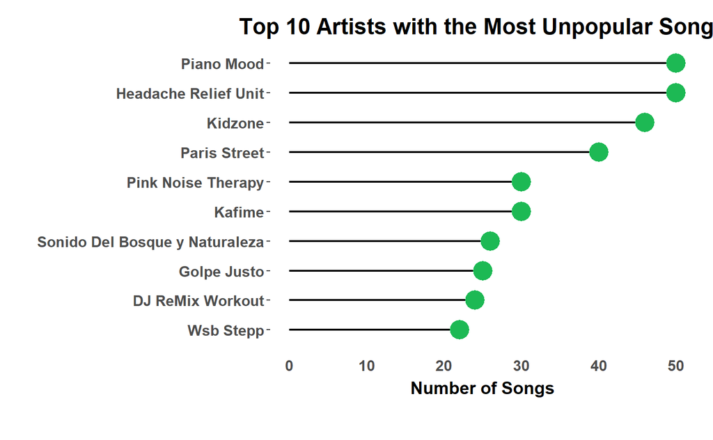

Finally, I combined the two in the same plot to have a complete plot.

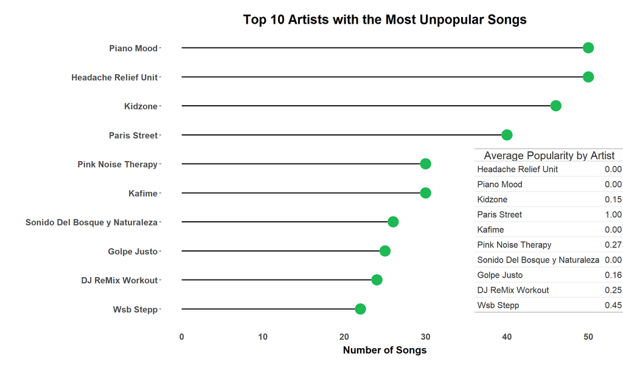

## How does popularity score varies across music keys? Can danceability explain the variation?

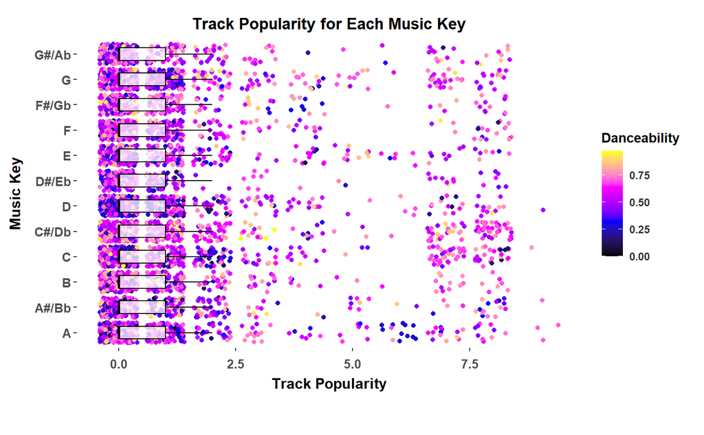